# Case Study

Cole Beck and Leena Choi

2022-05-24

# Introduction

We use a case study to demonstrate a statistical analysis and the accompanying statistical report. This study was published (Yanis *et al.*$^{1}$) and we use a modified (simulated) version of dataset that was used in the original study. The paper can be found at: https://onlinelibrary.wiley.com/doi/full/10.1111/tid.13772

## Summary of background, methods, and design (copied/edited from the paper$^{1}$)

Severe acute respiratory syndrome coronavirus 2 (SARS-CoV-2) infection is associated with increased morbidity and mortality in solid organ transplant (SOT) recipients. These individuals were identified as high-risk and prioritized for vaccination in public health guidelines.

Humoral and cellular immune responses to two doses of the SARS-CoV-2 mRNA vaccine, BNT162b2, in 52 SOT recipients and 26 healthy controls (HCs) were evaluated. Blood specimens collected from participants prior to each dose and following the second dose were tested for SARS-CoV-2-specific antibodies as well as CD4+ and CD8+ T-cell responses. For this case study, we will use modified data collected at baseline (0–2 days before first vaccine dose), post-dose 1 (21–42 days after first vaccine dose), and post-dose 2 (21–42 days after second vaccine dose).

## Outcome measures

Immunoglobulin G (IgG) to SARS-CoV-2 spike receptor-binding domain (RBD) and spike extracellular domain (ECD) was evaluated by enzyme-linked immunosorbent assay (ELISA). Cellular immune responses were quantified using CD4 and CD8 assays.

```r
library(Hmisc)
library(ggplot2)
library(gghalves)
```

```r
dat <- read.csv('sot-covid.csv')
# add labels to each variable: e.g., "mopost" variable
label(dat$mopost) <- 'months post-transplant'
label(dat$immuno) <- '# of immunosuppressants in patient’s treatment regiment'
label(dat$subj) <- 'participant identification number'
label(dat$organ) <- 'organ type (0 = healthy control, 1 = kidney, 2 = liver, 3 = heart, 4 = lung)'
label(dat$age) <- 'age (years)'
label(dat$male) <- 'gender (0 = female, 1 = male)'
label(dat$rbd1) <- 'ELISA response to RBD at baseline'
label(dat$rbd2) <- 'ELISA response to RBD three weeks following first vaccine dose'
label(dat$rbd3) <- 'ELISA response to RBD three weeks following second vaccine dose'
label(dat$ecd1) <- 'ELISA response to ECD at baseline'
label(dat$ecd2) <- 'ELISA response to ECD three weeks following first vaccine dose'
label(dat$ecd3) <- 'ELISA response to ECD three weeks following second vaccine dose'

# Remove subjects
dat <- dat[!(dat[,'subj'] %in% c(77,78)),]

# sot_hc = 1 for SOT, 0 for healthy
dat[,'sot_hc'] <- as.numeric(dat[,'organ'] != 0)
healthy_control <- dat[,'sot_hc'] == 0
dat[,'sot_hc'] <- factor(dat[,'sot_hc'], labels = c('Controls','SOT'))
label(dat$sot_hc) <- 'patient group: Controls vs. SOT (solid organ transplant))'

# Sort by subject ID
dat <- dat[order(dat[,'subj']),]

# Generate data for CD4 and CD8 counts
set.seed(3)
ndat <- nrow(dat)
nctrl <- sum(healthy_control)
dat[,'cd4ecd1'] <- rlnorm(ndat, meanlog=0.1, sdlog = 0.3)
dat[healthy_control, 'cd4ecd1'] <- rlnorm(nctrl, meanlog=0, sdlog = 0.3)
dat[,'cd4ecd3'] <- rlnorm(ndat,  meanlog=0, sdlog = 0.3)
dat[healthy_control, 'cd4ecd3'] <- rlnorm(nctrl, meanlog=0.3, sdlog = 0.3)
dat[,'cd8pep1'] <- rlnorm(ndat, meanlog=0, sdlog = 0.1)
dat[healthy_control, 'cd8pep1'] <- rlnorm(nctrl, meanlog=0, sdlog = 0.1)
dat[,'cd8pep3'] <- rlnorm(ndat, meanlog=0.07, sdlog = 0.1)
dat[healthy_control, 'cd8pep3'] <- rlnorm(nctrl, meanlog=0.2, sdlog = 0.1)

# create categorical variables with labels
dat[,'organ'] <- factor(dat[,'organ'], labels = c('healthy','kidney','liver','heart','lung'))
dat[,'sex'] <- factor(dat[,'male'], labels = c('F','M'))

# for healthy, instead of 0, set to missing
dat[healthy_control,'immuno'] <- NA
dat[healthy_control,'mopost'] <- NA
```

# Exploratory Analysis

## Descriptive statistics

```r
html(describe(demo))
```

demo  
7 Variables 78 Observations

subj: participant identification number

| n | missing | distinct | Info | Mean | Gmd | .05 | .10 | .25 | .50 | .75 | .90 | .95 |
| --- | --- | --- | --- | --- | --- | --- | --- | --- | --- | --- | --- | --- |
| 78 | 0 | 78 | 1 | 39.55 | 26.43 | 4.85 | 8.70 | 20.25 | 39.50 | 58.75 | 70.30 | 74.15 |

lowest : 1 2 3 4 5 , highest: 74 75 76 79 80

organ

| n | missing | distinct |
| --- | --- | --- |
| 78 | 0 | 5 |

lowest : healthy kidney liver heart lung , highest: healthy kidney liver heart lung

```
 Value      healthy  kidney   liver   heart    lung
 Frequency       26      22      21       6       3
 Proportion   0.333   0.282   0.269   0.077   0.038
```

immuno: # of immunosuppressants in patient’s treatment regiment

| n | missing | distinct | Info | Mean | Gmd |
| --- | --- | --- | --- | --- | --- |
| 52 | 26 | 3 | 0.715 | 1.423 | 0.5837 |

```
 Value          1     2     3
 Frequency     33    16     3
 Proportion 0.635 0.308 0.058
```

mopost: months post-transplant

| n | missing | distinct | Info | Mean | Gmd | .05 | .10 | .25 | .50 | .75 | .90 | .95 |
| --- | --- | --- | --- | --- | --- | --- | --- | --- | --- | --- | --- | --- |
| 52 | 26 | 20 | 0.991 | 9.269 | 8.456 | 1.00 | 1.00 | 3.00 | 7.00 | 13.75 | 19.90 | 22.35 |

lowest : 1 2 3 5 6 , highest: 20 21 24 27 30

```
 Value          1     2     3     5     6     7     8    10    11    12    13    16
 Frequency      9     2     7     2     2     5     3     2     2     3     2     3
 Proportion 0.173 0.038 0.135 0.038 0.038 0.096 0.058 0.038 0.038 0.058 0.038 0.058

 Value         17    18    19    20    21    24    27    30
 Frequency      1     2     1     1     2     1     1     1
 Proportion 0.019 0.038 0.019 0.019 0.038 0.019 0.019 0.019
```

age: age (years)

| n | missing | distinct | Info | Mean | Gmd | .05 | .10 | .25 | .50 | .75 | .90 | .95 |
| --- | --- | --- | --- | --- | --- | --- | --- | --- | --- | --- | --- | --- |
| 78 | 0 | 23 | 0.994 | 68.56 | 7.716 | 55.85 | 56.70 | 62.75 | 71.00 | 73.75 | 76.00 | 77.00 |

lowest : 53 54 55 56 57 , highest: 75 76 77 78 80

sex

| n | missing | distinct |
| --- | --- | --- |
| 78 | 0 | 2 |

```
 Value          F     M
 Frequency     40    38
 Proportion 0.513 0.487
```

sot_hc: patient group: Controls vs. SOT (solid organ transplant))

| n | missing | distinct |
| --- | --- | --- |
| 78 | 0 | 2 |

```
 Value      Controls      SOT
 Frequency        26       52
 Proportion    0.333    0.667
```

```r
html(describe(outcomes))
```

outcomes  
6 Variables 78 Observations

rbd1: ELISA response to RBD at baseline

```
        n  missing distinct     Info     Mean      Gmd      .05      .10      .25
       78        0       65        1   0.2132   0.1755  0.08355  0.08970  0.11725
      .50      .75      .90      .95
  0.14250  0.19950  0.33350  0.42690
```

lowest : 0.007 0.071 0.074 0.081 0.084 , highest: 0.426 0.432 0.664 1.209 2.418

rbd2: ELISA response to RBD three weeks following first vaccine dose

```
        n  missing distinct     Info     Mean      Gmd      .05      .10      .25
       78        0       75        1   0.5857   0.6288  0.06575  0.09330  0.13825
      .50      .75      .90      .95
  0.29450  0.94650  1.46310  1.79250
```

lowest : 0.044 0.049 0.051 0.053 0.068 , highest: 1.782 1.852 1.997 2.110 2.753

rbd3: ELISA response to RBD three weeks following second vaccine dose

| n | missing | distinct | Info | Mean | Gmd | .05 | .10 | .25 | .50 | .75 | .90 | .95 |
| --- | --- | --- | --- | --- | --- | --- | --- | --- | --- | --- | --- | --- |
| 78 | 0 | 77 | 1 | 1.255 | 1.112 | 0.0848 | 0.1128 | 0.2112 | 1.3010 | 2.2000 | 2.4511 | 2.6531 |

lowest : 0.059 0.060 0.076 0.078 0.086 , highest: 2.644 2.705 2.718 2.856 3.000

ecd1: ELISA response to ECD at baseline

```
        n  missing distinct     Info     Mean      Gmd      .05      .10      .25
       78        0       66        1   0.2262   0.1524  0.08955  0.10280  0.13325
      .50      .75      .90      .95
  0.17500  0.24525  0.31630  0.42960
```

lowest : 0.073 0.076 0.082 0.087 0.090 , highest: 0.417 0.501 0.549 0.796 2.020

ecd2: ELISA response to ECD three weeks following first vaccine dose

| n | missing | distinct | Info | Mean | Gmd | .05 | .10 | .25 | .50 | .75 | .90 | .95 |
| --- | --- | --- | --- | --- | --- | --- | --- | --- | --- | --- | --- | --- |
| 78 | 0 | 74 | 1 | 0.5777 | 0.5487 | 0.1038 | 0.1315 | 0.1900 | 0.3355 | 0.8845 | 1.3594 | 1.5713 |

lowest : 0.012 0.060 0.078 0.103 0.104 , highest: 1.568 1.590 1.646 1.786 2.486

ecd3: ELISA response to ECD three weeks following second vaccine dose

| n | missing | distinct | Info | Mean | Gmd | .05 | .10 | .25 | .50 | .75 | .90 | .95 |
| --- | --- | --- | --- | --- | --- | --- | --- | --- | --- | --- | --- | --- |
| 78 | 0 | 78 | 1 | 1.081 | 0.9011 | 0.1336 | 0.1685 | 0.2462 | 1.2315 | 1.8057 | 2.0506 | 2.1892 |

lowest : 0.003 0.093 0.095 0.131 0.134 , highest: 2.166 2.321 2.451 2.476 2.516

## Baseline demographic and clinical characteristics of healthy control (Controls) and solid organ transplant (SOT) groups

```r
html(summaryM(age + sex + immuno + organ + mopost ~ sot_hc, data = dat, continuous = 3), long = TRUE)
```

| Descriptive Statistics *(N=78)*. | Descriptive Statistics *(N=78)*. N | Descriptive Statistics *(N=78)*. Controls *N=26* | Descriptive Statistics *(N=78)*. SOT *N=52* |
| --- | --- | --- | --- |
| age (years) | 78 | 56.00 60.00 65.00 | 70.00 72.00 74.25 |
| sex | 78 |  |  |
| M |  | 0.65 (17) | 0.40 (21) |
| # of immunosuppressants in patient’s treatment regiment | 52 |  | 1 1 2 |
| organ | 78 |  |  |
| healthy |  | 1.00 (26) | 0.00 ( 0) |
| kidney |  | 0.00 ( 0) | 0.42 (22) |
| liver |  | 0.00 ( 0) | 0.40 (21) |
| heart |  | 0.00 ( 0) | 0.12 ( 6) |
| lung |  | 0.00 ( 0) | 0.06 ( 3) |
| months post-transplant | 52 |  | 3.00 7.00 13.75 |

*a* *b* *c* represent the lower quartile *a*, the median *b*, and the upper quartile *c* for continuous variables. *N* is the number of non-missing values. Numbers after proportions are frequencies.

## Humoral responses

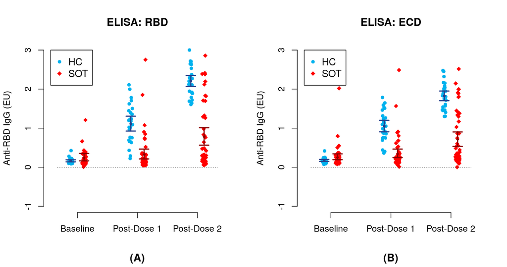

## Cellular responses and relationship with humoral responses

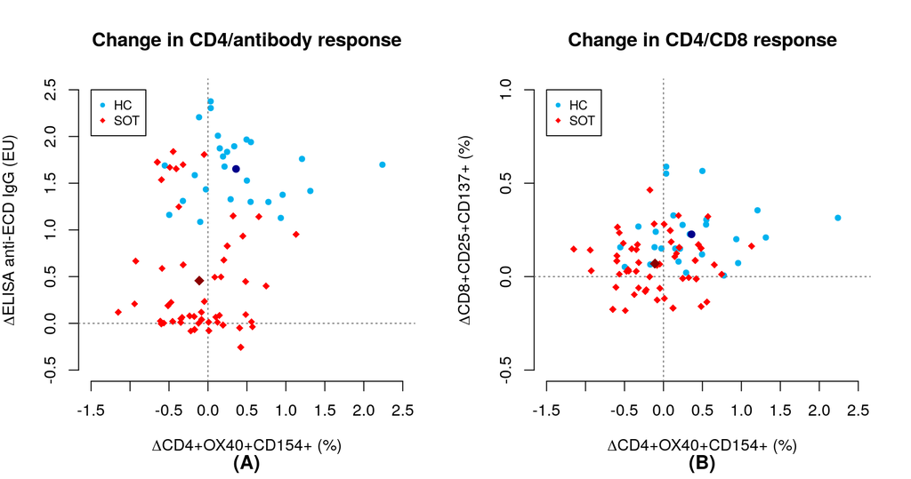

```r
vars <- grep('^(rbd|ecd)', names(dat), value = TRUE)
# take log(e) of variables
for(v in vars) {
  dat[,paste0('l', v)] <- log(dat[,v])
}
# take difference in first dose and baseline values
dat[,'rbd_diff12'] <- dat[,'rbd2'] - dat[,'rbd1']
dat[,'ecd_diff12'] <- dat[,'ecd2'] - dat[,'ecd1']
dat[,'lrbd_diff12'] <- dat[,'lrbd2'] - dat[,'lrbd1']
dat[,'lecd_diff12'] <- dat[,'lecd2'] - dat[,'lecd1']
```

## Histogram of ELISA response

### Original outcome measurements

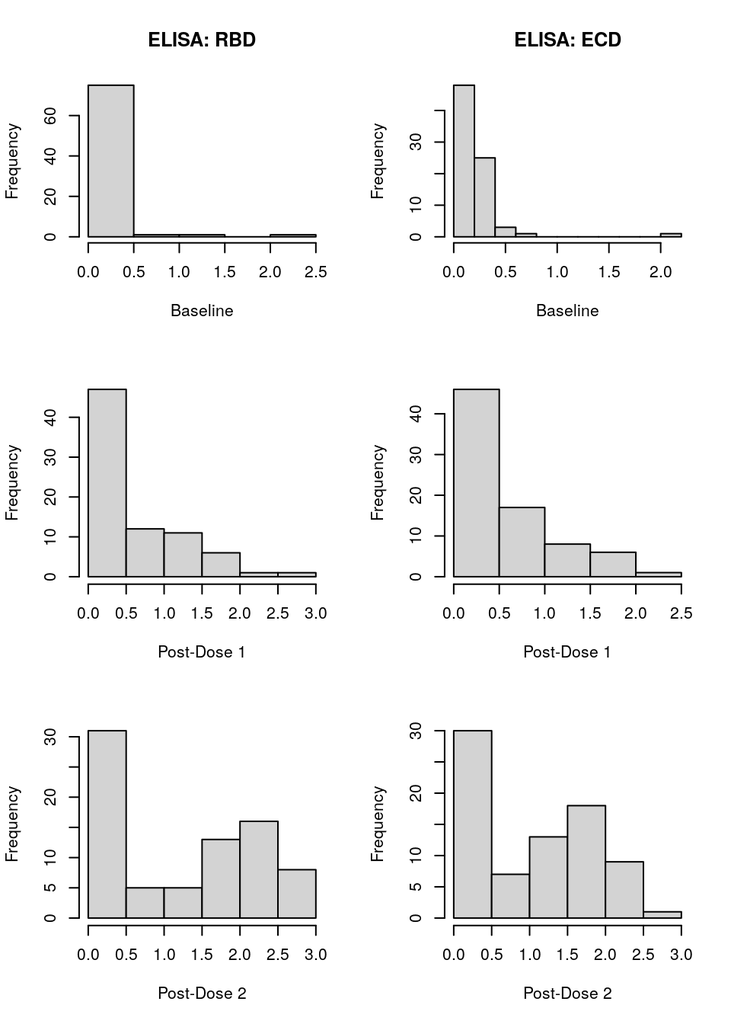

### Logarithmic transformation of the outcome measurements

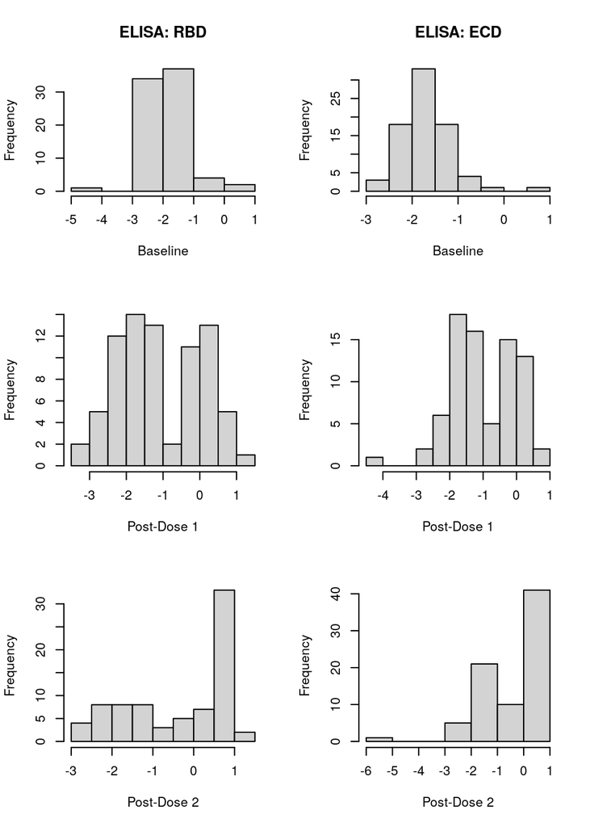

### Difference in outcomes between the baseline and the post-dose 1

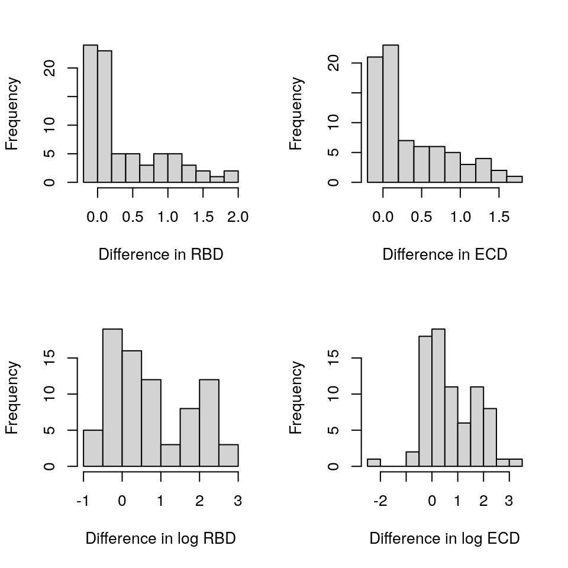

## Individual line plots

### RBD

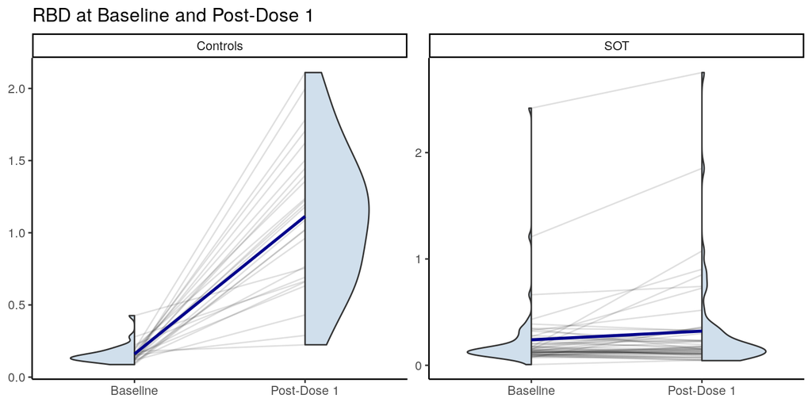

### ECD

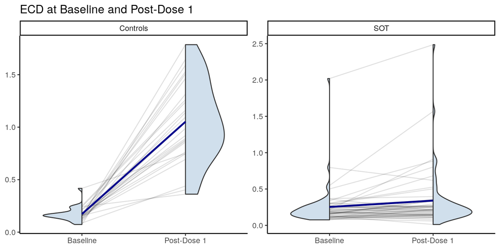

# Statistical Analysis

## Paired t-test

- To test the difference in the outcomes between the baseline and post-dose 1 for each patient group

### Control group

#### RBD

```r
t.test(dat$lrbd1[dat$sot_hc=="Controls"], dat$lrbd2[dat$sot_hc=="Controls"], paired = TRUE)
```

```
##
##  Paired t-test
##
## data:  dat$lrbd1[dat$sot_hc == "Controls"] and dat$lrbd2[dat$sot_hc == "Controls"]
## t = -13.665, df = 25, p-value = 4.221e-13
## alternative hypothesis: true mean difference is not equal to 0
## 95 percent confidence interval:
##  -2.162452 -1.596010
## sample estimates:
## mean difference
##       -1.879231
```

#### ECD

```r
t.test(dat$lecd1[dat$sot_hc=="Controls"], dat$lecd2[dat$sot_hc=="Controls"], paired = TRUE)
```

```
##
##  Paired t-test
##
## data:  dat$lecd1[dat$sot_hc == "Controls"] and dat$lecd2[dat$sot_hc == "Controls"]
## t = -15.157, df = 25, p-value = 4.145e-14
## alternative hypothesis: true mean difference is not equal to 0
## 95 percent confidence interval:
##  -2.040594 -1.552378
## sample estimates:
## mean difference
##       -1.796486
```

### Solid organ transplant group

#### RBD

```r
t.test(dat$lrbd1[dat$sot_hc=="SOT"], dat$lrbd2[dat$sot_hc=="SOT"], paired = TRUE)
```

```
##
##  Paired t-test
##
## data:  dat$lrbd1[dat$sot_hc == "SOT"] and dat$lrbd2[dat$sot_hc == "SOT"]
## t = -2.0844, df = 51, p-value = 0.04215
## alternative hypothesis: true mean difference is not equal to 0
## 95 percent confidence interval:
##  -0.356953605 -0.006698316
## sample estimates:
## mean difference
##       -0.181826
```

#### ECD

```r
t.test(dat$lecd1[dat$sot_hc=="SOT"], dat$lecd2[dat$sot_hc=="SOT"], paired = TRUE)
```

```
##
##  Paired t-test
##
## data:  dat$lecd1[dat$sot_hc == "SOT"] and dat$lecd2[dat$sot_hc == "SOT"]
## t = -1.9542, df = 51, p-value = 0.05617
## alternative hypothesis: true mean difference is not equal to 0
## 95 percent confidence interval:
##  -0.320139774  0.004311875
## sample estimates:
## mean difference
##      -0.1579139
```

## Two sample t-test

- To test the difference in the outcomes between controls vs. solid organ transplant groups

#### RBD

```r
t.test(lrbd_diff12 ~ sot_hc, data = dat)
```

```
##
##  Welch Two Sample t-test
##
## data:  lrbd_diff12 by sot_hc
## t = 10.423, df = 45.552, p-value = 1.206e-13
## alternative hypothesis: true difference in means between group Controls and group SOT is not equal to 0
## 95 percent confidence interval:
##  1.369516 2.025295
## sample estimates:
## mean in group Controls      mean in group SOT
##               1.879231               0.181826
```

#### ECD

```r
t.test(lecd_diff12 ~ sot_hc, data = dat)
```

```
##
##  Welch Two Sample t-test
##
## data:  lecd_diff12 by sot_hc
## t = 11.423, df = 48.504, p-value = 2.348e-15
## alternative hypothesis: true difference in means between group Controls and group SOT is not equal to 0
## 95 percent confidence interval:
##  1.350223 1.926921
## sample estimates:
## mean in group Controls      mean in group SOT
##              1.7964858              0.1579139
```

## Multiple linear regression

- To test the difference in the outcomes between controls vs. solid organ transplant groups after adjusting for the baseline measurement and covariates

#### RBD

```r
fit1 <- lm(lrbd ~ sot_hc + lrbd_base + age + male, data = lrbd.long12)
summary(fit1)
```

```
##
## Call:
## lm(formula = lrbd ~ sot_hc + lrbd_base + age + male, data = lrbd.long12)
##
## Residuals:
## ELISA response to RBD at baseline
##      Min       1Q   Median       3Q      Max
## -1.04924 -0.30843 -0.09531  0.20294  1.80605
##
## Coefficients:
##              Estimate Std. Error t value Pr(>|t|)
## (Intercept)  0.766039   0.737311   1.039    0.300
## sot_hcSOT   -0.787409   0.171796  -4.583 9.52e-06 ***
## lrbd_base    0.872263   0.084436  10.330  < 2e-16 ***
## age         -0.002296   0.011611  -0.198    0.844
## male         0.111340   0.119052   0.935    0.351
## ---
## Signif. codes:  0 '***' 0.001 '**' 0.01 '*' 0.05 '.' 0.1 ' ' 1
##
## Residual standard error: 0.7161 on 151 degrees of freedom
## Multiple R-squared:  0.4951, Adjusted R-squared:  0.4817
## F-statistic: 37.01 on 4 and 151 DF,  p-value: < 2.2e-16
```

#### ECD

```r
fit2 <- lm(lecd ~ sot_hc + lecd_base + age + male, data = lecd.long12)
summary(fit2)
```

```
##
## Call:
## lm(formula = lecd ~ sot_hc + lecd_base + age + male, data = lecd.long12)
##
## Residuals:
## ELISA response to ECD at baseline
##      Min       1Q   Median       3Q      Max
## -2.41829 -0.22327 -0.07653  0.28336  2.09879
##
## Coefficients:
##               Estimate Std. Error t value Pr(>|t|)
## (Intercept)  0.8899107  0.7122656   1.249    0.213
## sot_hcSOT   -0.8259330  0.1638834  -5.040 1.32e-06 ***
## lecd_base    0.9337224  0.1057261   8.832 2.43e-15 ***
## age         -0.0006462  0.0108754  -0.059    0.953
## male        -0.1110924  0.1131074  -0.982    0.328
## ---
## Signif. codes:  0 '***' 0.001 '**' 0.01 '*' 0.05 '.' 0.1 ' ' 1
##
## Residual standard error: 0.6726 on 151 degrees of freedom
## Multiple R-squared:  0.4129, Adjusted R-squared:  0.3974
## F-statistic: 26.55 on 4 and 151 DF,  p-value: < 2.2e-16
```

# Model Diagnostics

- Model diagnostics will be learned in other lectures.

# References

1. Yanis A, Haddadin Z, Spieker AJ, Waqfi D, Rankin DA, Talj R, Thomas L, Birdwell KA, Ezzell L, Blair M, Eason J, Varjabedian R, Warren CM, Nochowicz CH, Olson EC, Simmons JD, Yoder S, Guy M, Thomsen I, Chappell JD, Kalams SA, Halasa NB. Humoral and cellular immune responses to the SARS-CoV-2 BNT162b2 vaccine among a cohort of solid organ transplant recipients and healthy controls. Transpl Infect Dis. 2022 Feb;24(1):e13772. doi: 10.1111/tid.13772. Epub 2021 Dec 21.